# Fashion MNIST 数据集

Fashion MNIST数据集是一个包含时尚图像的数据库，旨在取代简单的MNIST数字数据集，以提供更具挑战性的分类任务。它被用于训练和测试各种机器学习算法。

Fashion MNIST数据集由70,000张28x28像素的灰度时尚产品图像组成，分为10个类别，每个类别包含7,000张图像。训练集包含60,000张图像，测试集包含10,000张图像。

```python
import numpy as np
import tensorflow as tf
import pandas as pd
import warnings
from matplotlib import pyplot as plt
warnings.filterwarnings('ignore', category=FutureWarning)
```

从本地导入Fashion MNIST数据集

```python
path1 = 'C:\\Users\\13838\\.keras\\datasets\\fashion-mnist\\fashion-mnist_train.csv'
df_train=pd.read_csv(path1)

path2 = 'C:\\Users\\13838\\.keras\\datasets\\fashion-mnist\\fashion-mnist_test.csv'
df_test=pd.read_csv(path2)
```

```python
df_train.head()
```

|  | label | pixel1 | pixel2 | pixel3 | pixel4 | pixel5 | pixel6 | pixel7 | pixel8 | pixel9 | ... | pixel775 | pixel776 | pixel777 | pixel778 | pixel779 | pixel780 | pixel781 | pixel782 | pixel783 | pixel784 |
| --- | --- | --- | --- | --- | --- | --- | --- | --- | --- | --- | --- | --- | --- | --- | --- | --- | --- | --- | --- | --- | --- |
| 0 | 2 | 0 | 0 | 0 | 0 | 0 | 0 | 0 | 0 | 0 | ... | 0 | 0 | 0 | 0 | 0 | 0 | 0 | 0 | 0 | 0 |
| 1 | 9 | 0 | 0 | 0 | 0 | 0 | 0 | 0 | 0 | 0 | ... | 0 | 0 | 0 | 0 | 0 | 0 | 0 | 0 | 0 | 0 |
| 2 | 6 | 0 | 0 | 0 | 0 | 0 | 0 | 0 | 5 | 0 | ... | 0 | 0 | 0 | 30 | 43 | 0 | 0 | 0 | 0 | 0 |
| 3 | 0 | 0 | 0 | 0 | 1 | 2 | 0 | 0 | 0 | 0 | ... | 3 | 0 | 0 | 0 | 0 | 1 | 0 | 0 | 0 | 0 |
| 4 | 3 | 0 | 0 | 0 | 0 | 0 | 0 | 0 | 0 | 0 | ... | 0 | 0 | 0 | 0 | 0 | 0 | 0 | 0 | 0 | 0 |

5 rows × 785 columns

```python
df_test.head()
```

|  | label | pixel1 | pixel2 | pixel3 | pixel4 | pixel5 | pixel6 | pixel7 | pixel8 | pixel9 | ... | pixel775 | pixel776 | pixel777 | pixel778 | pixel779 | pixel780 | pixel781 | pixel782 | pixel783 | pixel784 |
| --- | --- | --- | --- | --- | --- | --- | --- | --- | --- | --- | --- | --- | --- | --- | --- | --- | --- | --- | --- | --- | --- |
| 0 | 9 | 0 | 0 | 0 | 0 | 0 | 0 | 0 | 0 | 0 | ... | 0 | 0 | 0 | 0 | 0 | 0 | 0 | 0 | 0 | 0 |
| 1 | 2 | 0 | 0 | 0 | 0 | 0 | 0 | 0 | 0 | 0 | ... | 2 | 3 | 0 | 3 | 174 | 189 | 67 | 0 | 0 | 0 |
| 2 | 1 | 0 | 0 | 0 | 0 | 0 | 0 | 0 | 0 | 1 | ... | 164 | 58 | 0 | 0 | 0 | 0 | 0 | 0 | 0 | 0 |
| 3 | 1 | 0 | 0 | 0 | 0 | 0 | 0 | 0 | 0 | 0 | ... | 1 | 0 | 0 | 0 | 0 | 0 | 0 | 0 | 0 | 0 |
| 4 | 6 | 0 | 0 | 0 | 2 | 0 | 1 | 1 | 0 | 0 | ... | 71 | 12 | 0 | 0 | 0 | 0 | 0 | 0 | 0 | 0 |

5 rows × 785 columns

接下来，把训练集和测试集加载到不同的变量中。

```python
X_train=df_train.iloc[:,1:]
y_train=df_train.iloc[:,0]

X_test=df_test.iloc[:,1:]
y_test=df_test.iloc[:,0]
```

```python
X_train
```

|  | pixel1 | pixel2 | pixel3 | pixel4 | pixel5 | pixel6 | pixel7 | pixel8 | pixel9 | pixel10 | ... | pixel775 | pixel776 | pixel777 | pixel778 | pixel779 | pixel780 | pixel781 | pixel782 | pixel783 | pixel784 |
| --- | --- | --- | --- | --- | --- | --- | --- | --- | --- | --- | --- | --- | --- | --- | --- | --- | --- | --- | --- | --- | --- |
| 0 | 0 | 0 | 0 | 0 | 0 | 0 | 0 | 0 | 0 | 0 | ... | 0 | 0 | 0 | 0 | 0 | 0 | 0 | 0 | 0 | 0 |
| 1 | 0 | 0 | 0 | 0 | 0 | 0 | 0 | 0 | 0 | 0 | ... | 0 | 0 | 0 | 0 | 0 | 0 | 0 | 0 | 0 | 0 |
| 2 | 0 | 0 | 0 | 0 | 0 | 0 | 0 | 5 | 0 | 0 | ... | 0 | 0 | 0 | 30 | 43 | 0 | 0 | 0 | 0 | 0 |
| 3 | 0 | 0 | 0 | 1 | 2 | 0 | 0 | 0 | 0 | 0 | ... | 3 | 0 | 0 | 0 | 0 | 1 | 0 | 0 | 0 | 0 |
| 4 | 0 | 0 | 0 | 0 | 0 | 0 | 0 | 0 | 0 | 0 | ... | 0 | 0 | 0 | 0 | 0 | 0 | 0 | 0 | 0 | 0 |
| ... | ... | ... | ... | ... | ... | ... | ... | ... | ... | ... | ... | ... | ... | ... | ... | ... | ... | ... | ... | ... | ... |
| 59995 | 0 | 0 | 0 | 0 | 0 | 0 | 0 | 0 | 0 | 0 | ... | 0 | 0 | 0 | 0 | 0 | 0 | 0 | 0 | 0 | 0 |
| 59996 | 0 | 0 | 0 | 0 | 0 | 0 | 0 | 0 | 0 | 0 | ... | 73 | 0 | 0 | 0 | 0 | 0 | 0 | 0 | 0 | 0 |
| 59997 | 0 | 0 | 0 | 0 | 0 | 0 | 0 | 0 | 0 | 0 | ... | 160 | 162 | 163 | 135 | 94 | 0 | 0 | 0 | 0 | 0 |
| 59998 | 0 | 0 | 0 | 0 | 0 | 0 | 0 | 0 | 0 | 0 | ... | 0 | 0 | 0 | 0 | 0 | 0 | 0 | 0 | 0 | 0 |
| 59999 | 0 | 0 | 0 | 0 | 0 | 0 | 0 | 0 | 0 | 0 | ... | 0 | 0 | 0 | 0 | 0 | 0 | 0 | 0 | 0 | 0 |

60000 rows × 784 columns

```python
y_train
```

```
0        2
1        9
2        6
3        0
4        3
        ..
59995    9
59996    1
59997    8
59998    8
59999    7
Name: label, Length: 60000, dtype: int64
```

现在来查看训练集和测试集的维度

```python
print('Fashion MNIST Dataset Shape:')
print('X_train: ' + str(X_train.shape))
print('Y_train: ' + str(y_train.shape))
print('X_test:  '  + str(X_test.shape))
print('Y_test:  '  + str(y_test.shape))
```

```
Fashion MNIST Dataset Shape:
X_train: (60000, 784)
Y_train: (60000,)
X_test:  (10000, 784)
Y_test:  (10000,)
```

训练集中有60,000张图像，测试集中有10,000张图像，每张图像的尺寸是28 x 28。

## 数据集的标签

我将查看数据集可能的类别，并且还将恢复它们的索引，以便访问X_train中对应的图像。我将保存每个类别出现的索引在一个名为position_label的变量中。

```python
label, position_label = np.unique(y_train, return_index = True)
print("The possible labels are {} \nTheir indexes are {}".format(label,position_label))
```

```
The possible labels are [0 1 2 3 4 5 6 7 8 9]
Their indexes are [ 3 29  0  4  5  7  2 21  9  1]
```

### 标准缩放器

现在我将使用标准化的数据，所有数据将具有零均值和单位标准差。

缩放是分别应用于每一列的，即对于每个特征，我们减去其均值并除以标准差。

```python
from sklearn.preprocessing import StandardScaler

scaler = StandardScaler()
scaler.fit(X_train)

X_train_scaled = scaler.transform(X_train)


X_test_scaled = scaler.transform(X_test)
```

然后，对数据集取样，以减少处理时间，而不是分析整个数据集。

```python
indices_train = np.random.choice(X_train_scaled.shape[0], 18000, replace=False)

X_train_scaled_sample = X_train_scaled[indices_train]
y_train_sample = y_train[indices_train]

indices_test =  np.random.choice(X_test_scaled.shape[0], 3000, replace=False)
X_test_scaled_sample = X_test_scaled[indices_test]
y_test_sample = y_test[indices_test]
```

检查训练集和测试集中标签的分布情况。

```python
labels_train, count_train = np.unique(y_train_sample, return_counts = True)
```

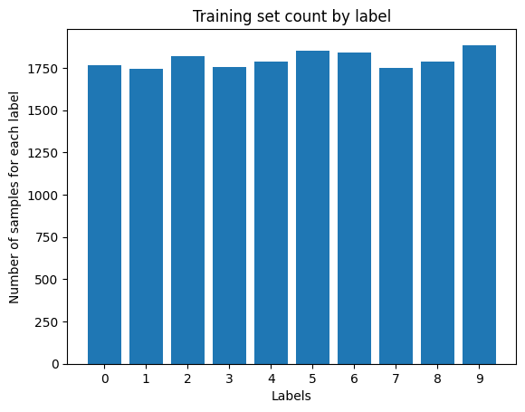

```python
plt.bar(labels_train,count_train)
plt.xlabel('Labels')
plt.ylabel('Number of samples for each label')
plt.title('Training set count by label')
plt.xticks(labels_train)
plt.show()
```

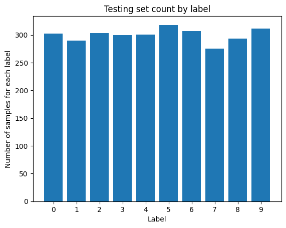

```python
labels_test, count_test = np.unique(y_test_sample, return_counts = True)
plt.bar(labels_test,count_test)
plt.xlabel('Label')
plt.ylabel('Number of samples for each label')
plt.title('Testing set count by label')
plt.xticks(labels_test)
plt.show()
```

# KNN 算法

首先，我将确定在 KNN 算法中使用哪个超参数。为了说明确定合适的neighbors数量值的重要性，我将从将 n_neighbors 设置为 1 开始实现 KNN 算法。

```python
from sklearn.neighbors import KNeighborsClassifier
import time

KNN = KNeighborsClassifier(n_neighbors = 1)
```

```python
start = time.time()
KNN.fit(X_train_scaled_sample, y_train_sample)
elapsed_time = time.time() - start
```

计算模型在训练集和测试集中的准确率。

```python
accuracy_training = KNN.score(X_train_scaled_sample,y_train_sample)
```

```python
accuracy_test = KNN.score(X_test_scaled_sample,y_test_sample)
```

```python
print("The accuracy of KNN on the training set is {:.4f} with a fitting time of {:.2f} s".format(accuracy_training, elapsed_time))

print("The accuracy on the test set is {:.4f}".format(accuracy_test))
```

```
The accuracy of KNN on the training set is 1.0000 with a fitting time of 0.02 s
The accuracy on the test set is 0.8553
```

正如可以看到的那样，训练集的准确率为1，这表明我们存在过拟合，暗示模型记忆了训练数据而不是学习底层模式，导致对新的、未见过的数据的泛化能力较低。

为了建立一个更好的选择neighbors数量的标准，我将计算不同neighbors数量（从2到19）的得分。这个范围将有助于确定模型在过拟合和欠拟合之间平衡的点，这应该对应于KNN算法的最佳neighbors数量。

```python
neighbors = list(range(2,20))
train_score = {}
test_score = {}
for i in neighbors:
    KNN = KNeighborsClassifier(n_neighbors=i)
    KNN.fit(X_train_scaled_sample ,y_train_sample)
    train_score[i]=KNN.score(X_train_scaled_sample , y_train_sample)*100
    test_score[i]=KNN.score(X_test_scaled_sample, y_test_sample)*100
    print("Neighbors {};  score training: {:.2f}%; score testing: {:.2f}%".format(i,train_score[i],test_score[i]))
```

```
Neighbors 2;  score training: 92.14%; score testing: 84.10%
Neighbors 3;  score training: 90.58%; score testing: 84.07%
Neighbors 4;  score training: 89.63%; score testing: 84.00%
Neighbors 5;  score training: 88.31%; score testing: 83.53%
Neighbors 6;  score training: 87.87%; score testing: 83.37%
Neighbors 7;  score training: 87.31%; score testing: 82.80%
Neighbors 8;  score training: 86.96%; score testing: 83.23%
Neighbors 9;  score training: 86.40%; score testing: 82.80%
Neighbors 10;  score training: 86.04%; score testing: 82.57%
Neighbors 11;  score training: 85.69%; score testing: 82.33%
Neighbors 12;  score training: 85.41%; score testing: 82.30%
Neighbors 13;  score training: 85.17%; score testing: 82.37%
Neighbors 14;  score training: 85.13%; score testing: 82.50%
Neighbors 15;  score training: 84.72%; score testing: 82.03%
Neighbors 16;  score training: 84.57%; score testing: 81.90%
Neighbors 17;  score training: 84.28%; score testing: 81.83%
Neighbors 18;  score training: 84.26%; score testing: 81.73%
Neighbors 19;  score training: 84.02%; score testing: 81.63%
```

```python
train_scores = [train_score[i] for i in neighbors]
test_scores = [test_score[i] for i in neighbors]
```

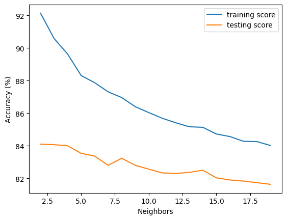

```python
plt.plot(neighbors,train_scores, label = 'training score')
plt.plot(neighbors,test_scores, label = 'testing score')
plt.legend(loc='upper right')
plt.xlabel('Neighbors')
plt.ylabel('Accuracy (%)')
plt.show()
```

我们的目标是找到最佳的neighbors数量，以尽可能提高测试集的准确率，同时确保训练和测试得分之间的差距不大。如果差距很大，可能表示模型过拟合。

### 使用GridSearchCV进行模型参数的超调优

为了找到改进KNN模型准确率的最佳超参数，我们可以对训练集进行网格搜索。通过设置GridSearchCV的cv=5，我们指定网格搜索应使用5折交叉验证。这意味着对于每个候选的n_neighbors值，训练集将被分成5个部分，模型将在其中4个部分上进行训练，并在第5个部分上进行验证，依次循环，直到每个部分都用于验证。param_grid设置为测试n_neighbors从2到19的范围。网格搜索将评估此范围内的所有可能值，以找到产生最佳交叉验证准确率的最佳neighbors数量。

```python
from sklearn.model_selection import GridSearchCV
param_grid = {'n_neighbors': np.arange(2, 20)}
knn_gscv = GridSearchCV(KNN, param_grid)
knn_gscv.fit(X_train_scaled_sample ,y_train_sample)
```

```
GridSearchCV(estimator=KNeighborsClassifier(n_neighbors=19),
             param_grid={'n_neighbors': array([ 2,  3,  4,  5,  6,  7,  8,  9, 10, 11, 12, 13, 14, 15, 16, 17, 18,
       19])})
```

执行这段代码后，knn_gscv.best_params_将提供在交叉验证过程中获得的平均准确率最高的n_neighbors值。

```python
knn_gscv.best_params_
```

```
{'n_neighbors': 6}
```

可以看到，6是最佳的'n_neighbors'值

## 补充说明

为这个任务，我创建了一个具有以下版本的新环境：

- numpy 1.19.5
- tensorflow 2.3
- pandas 1.1
- python 3.8
- matplotlib 3.6.2